# ch9 Lab

# Support Vector Machine

Lets study non-linear kernels

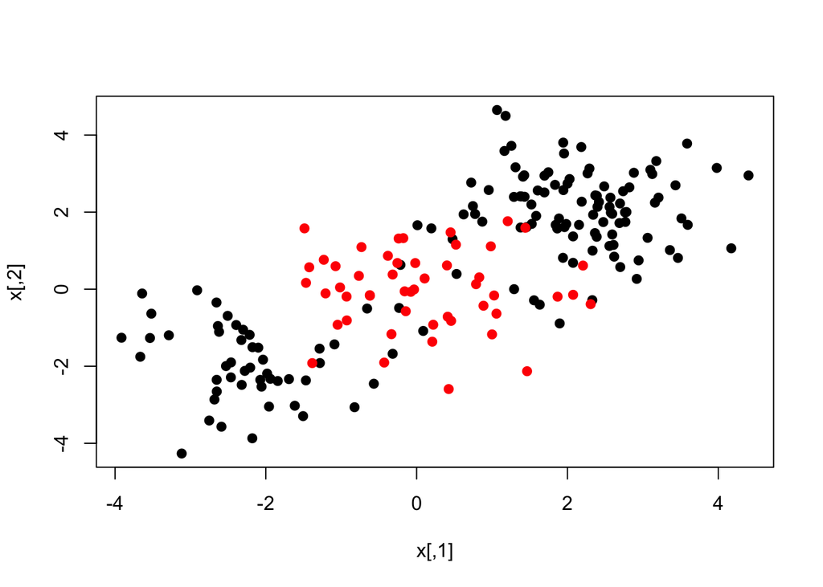

```r
set.seed(1)
# 200x2 matrix
x<-matrix(rnorm(200*2),ncol=2)
x[1:100,] <- x[1:100,] + 2 #first half of lines strongly separated
x[101:150,] <- x[101:150,] -2 #next 50 lines also separated but in opposite direction
y<-c(rep(1,150), rep(2,50))
dat<-data.frame(x=x,y=as.factor(y))

plot(x,col=y, pch=19)
```

Lets see the svm fit with radial kernel

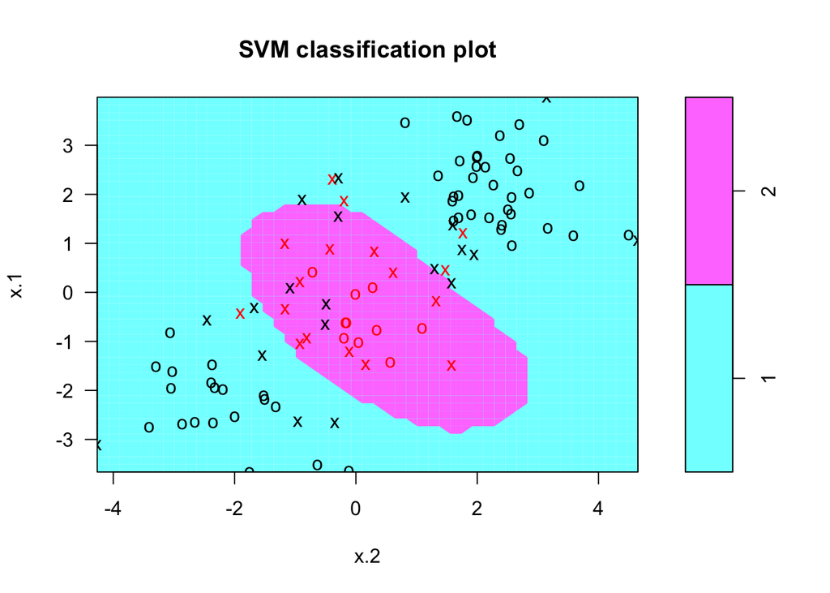

```r
train <- sample(1:nrow(dat),nrow(dat)/2) #half half
cst <- 1
svmfit <- svm(y~., data=dat[train,], kernel="radial", cost=cst, gamma=1)

plot(svmfit,dat[train,])
```

```r
summary(svmfit)
```

```
##
## Call:
## svm(formula = y ~ ., data = dat[train, ], kernel = "radial",
##     cost = cst, gamma = 1)
##
##
## Parameters:
##    SVM-Type:  C-classification
##  SVM-Kernel:  radial
##        cost:  1
##       gamma:  1
##
## Number of Support Vectors:  37
##
##  ( 17 20 )
##
##
## Number of Classes:  2
##
## Levels:
##  1 2
```

If you reduce margin, the decision boundary becomes more irregular

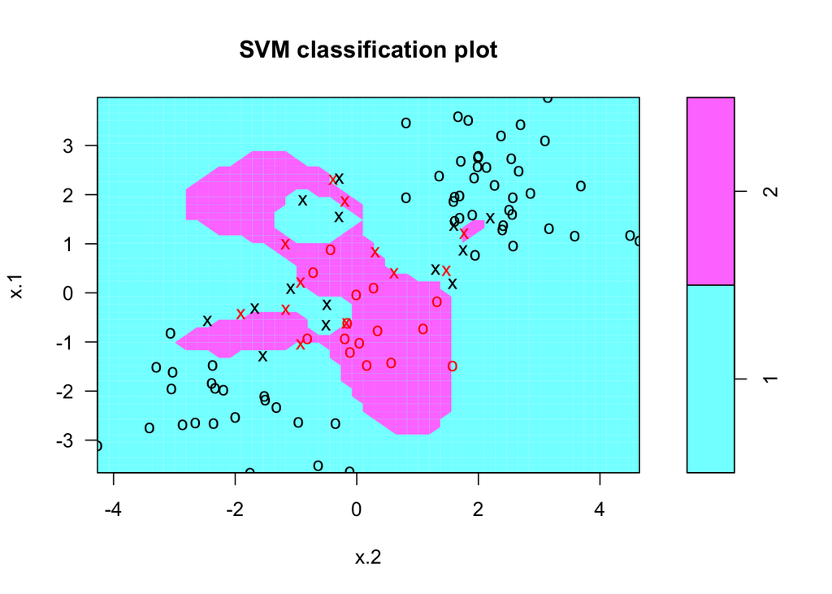

```r
cst <- 1e5
svmfit <- svm(y~., data=dat[train,], kernel="radial", cost=cst, gamma=1)
plot(svmfit,dat[train,])
```

Lets do the cross-validation with radial kernel

```r
set.seed(1)
tune.out <- tune(svm, y~., data=dat[train,], kernel="radial",
             ranges=list(cost=c(0.1, 1,10,100,1000),
             gamma=c(0.5,1,2,3,4)) )
print(summary(tune.out))
```

```
##
## Parameter tuning of 'svm':
##
## - sampling method: 10-fold cross validation
##
## - best parameters:
##  cost gamma
##     1     2
##
## - best performance: 0.12
##
## - Detailed performance results:
##     cost gamma error dispersion
## 1  1e-01   0.5  0.27 0.11595018
## 2  1e+00   0.5  0.13 0.08232726
## 3  1e+01   0.5  0.15 0.07071068
## 4  1e+02   0.5  0.17 0.08232726
## 5  1e+03   0.5  0.21 0.09944289
## 6  1e-01   1.0  0.25 0.13540064
## 7  1e+00   1.0  0.13 0.08232726
## 8  1e+01   1.0  0.16 0.06992059
## 9  1e+02   1.0  0.20 0.09428090
## 10 1e+03   1.0  0.20 0.08164966
## 11 1e-01   2.0  0.25 0.12692955
## 12 1e+00   2.0  0.12 0.09189366
## 13 1e+01   2.0  0.17 0.09486833
## 14 1e+02   2.0  0.19 0.09944289
## 15 1e+03   2.0  0.20 0.09428090
## 16 1e-01   3.0  0.27 0.11595018
## 17 1e+00   3.0  0.13 0.09486833
## 18 1e+01   3.0  0.18 0.10327956
## 19 1e+02   3.0  0.21 0.08755950
## 20 1e+03   3.0  0.22 0.10327956
## 21 1e-01   4.0  0.27 0.11595018
## 22 1e+00   4.0  0.15 0.10801234
## 23 1e+01   4.0  0.18 0.11352924
## 24 1e+02   4.0  0.21 0.08755950
## 25 1e+03   4.0  0.24 0.10749677
```

```r
#best params choice cost=1 gamma=2

cm <- table(true=dat[-train,"y"], pred=predict(tune.out$best.model ,newdata=dat[-train,]))
print(cm)
```

```
##     pred
## true  1  2
##    1 74  3
##    2  7 16
```

```r
print(paste("radial cost=1 gamma=2 svm accuracy:", sum(diag(cm))/sum(cm) ))
```

```
## [1] "radial cost=1 gamma=2 svm accuracy: 0.9"
```

Check the Very high accurancy

# ROC curves

```r
require(ROCR)
```

```r
#define a func to make roc plot
rocplot <- function(pred,truth, ...){
    predob <- prediction(pred,truth)
    perf <- performance(predob, "tpr", "fpr")
    plot(perf,...)
}
```

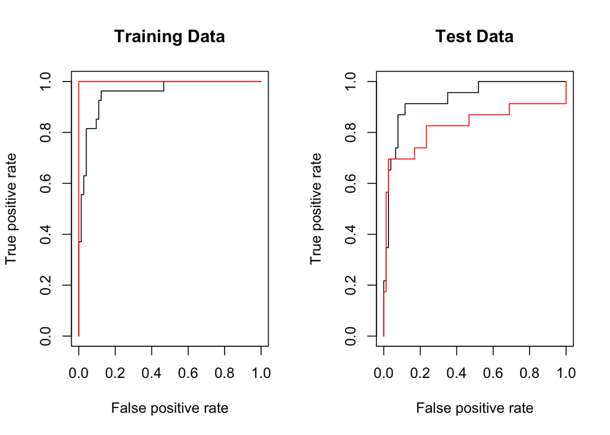

```r
svmfit.opt <- svm(y ~ . ,data=dat[train,], kernel="radial", gamma=2, cost=1  )
pred <- predict(svmfit.opt, dat[train,], decision.values = TRUE)
fitted <- attributes(pred)$decision.values

par(mfrow=c(1,2))

rocplot(fitted, dat[train,"y"], main="Training Data")

#lets increase gamma to 50
svmfit.flex <- svm(y ~ . ,data=dat[train,], kernel="radial", gamma=50, cost=1  )
pred <- predict(svmfit.flex, dat[train,], decision.values = TRUE)
fitted <- attributes(pred)$decision.values
rocplot(fitted, dat[train,"y"], add=T, col="red")

#lets check roc on test data
tpred <- predict(svmfit.opt, dat[-train,], decision.values = TRUE)
fitted <- attributes(tpred)$decision.values
rocplot(fitted, dat[-train,"y"], main="Test Data")

tpred <- predict(svmfit.flex, dat[-train,], decision.values = TRUE)
fitted <- attributes(tpred)$decision.values
rocplot(fitted, dat[-train,"y"], add=T, col="red")
```

We see that on test data the best results are with $\gamma=2$.

# SVM with Multiple Classes

Lets add a 3rd class

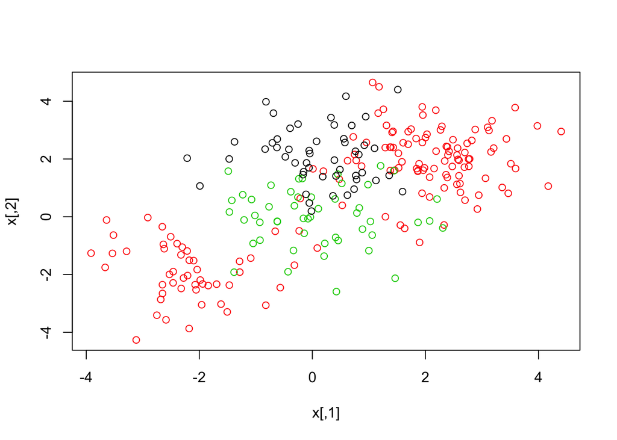

```r
set.seed(1)
x<-rbind(x,matrix(rnorm(50*2),ncol=2)) #more 50 lines
y<-c(y,rep(0,50))
x[y==0,2] <- x[y==0,2] + 2

dat <- data.frame(x=x,y=as.factor(y))
par(mfrow=c(1,1))
plot(x,col=(y+1))
```

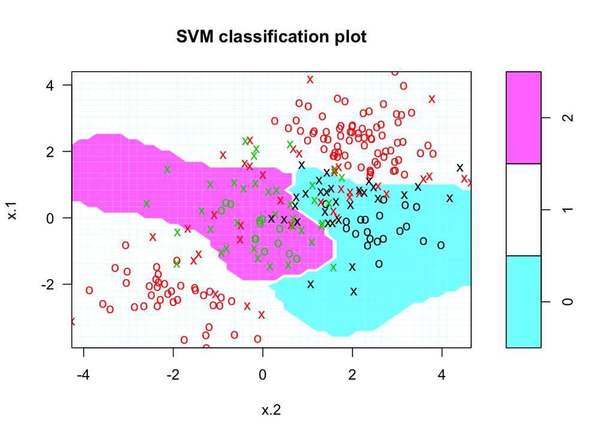

```r
#now lets fit
svmfit <- svm(y~., data=dat, kernel="radial", cost=10, gamma=1)
plot(svmfit,dat)
```

# Application to Gene Expression Data

```r
require(ISLR)
data(Khan)  #  63 rows, 2308 features
print(names(Khan))
```

```
## [1] "xtrain" "xtest"  "ytrain" "ytest"
```

```r
print(dim(Khan$xtrain))
```

```
## [1]   63 2308
```

```r
print(dim(Khan$xtest))
```

```
## [1]   20 2308
```

```r
#ytrain, ytest contain cancer subtype
print(table(Khan$ytrain))
```

```
##
##  1  2  3  4
##  8 23 12 20
```

```r
print(table(Khan$ytest))
```

```
##
## 1 2 3 4
## 3 6 6 5
```

```r
dat <- data.frame(x=Khan$xtrain, y=as.factor(Khan$ytrain))
out <- svm(y~., data=dat, kernel="linear", cost=10)
print(summary(out))
```

```
##
## Call:
## svm(formula = y ~ ., data = dat, kernel = "linear", cost = 10)
##
##
## Parameters:
##    SVM-Type:  C-classification
##  SVM-Kernel:  linear
##        cost:  10
##       gamma:  0.0004332756
##
## Number of Support Vectors:  58
##
##  ( 20 20 11 7 )
##
##
## Number of Classes:  4
##
## Levels:
##  1 2 3 4
```

Lets check confusion matrix on train and test data

```r
cm <- table(out$fitted, dat$y)
print( cm ) #no training errors
```

```
##
##      1  2  3  4
##   1  8  0  0  0
##   2  0 23  0  0
##   3  0  0 12  0
##   4  0  0  0 20
```

```r
print(paste("gene train data accuracy:", sum(diag(cm))/sum(cm) ))
```

```
## [1] "gene train data accuracy: 1"
```

```r
#lets check prediction on test data
dat.te <- data.frame(x=Khan$xtest, y=as.factor(Khan$ytest))
pred.te <- predict(out, dat.te)
cm <- table(pred.te, dat.te$y)
print( cm )
```

```
##
## pred.te 1 2 3 4
##       1 3 0 0 0
##       2 0 6 2 0
##       3 0 0 4 0
##       4 0 0 0 5
```

```r
print(paste("gene test data accuracy:", sum(diag(cm))/sum(cm) ))
```

```
## [1] "gene test data accuracy: 0.9"
```

2 errors on test data with `cost=10`